# Streamwater Data

Mia Forsline, Desik Somasundaram, Alex Vand

2021-08-27

Contact: mforsline@bren.ucsb.edu, desik@bren.ucsb.edu, asy@bren.ucsb.edu

# Background Information & Objective

Our research focuses on comparing K and NO3 concentrations at the different sites before and after Hurricane Hugo in September 1989.

## Collaborative workflow

Data is stored on our shared server at Bren (Taylor) and our repository is git-controlled on github and enabled us to access through our personal accounts on the Taylor server.

### Initial approach

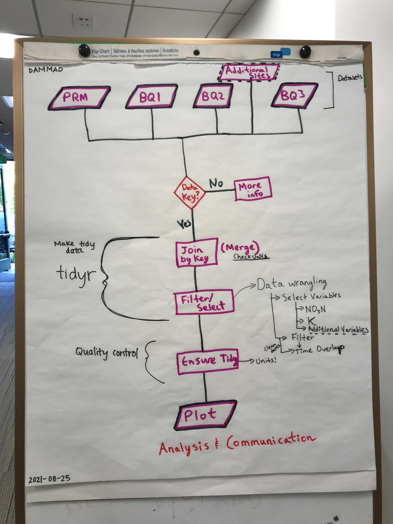

Old Workflow.

### Final approach

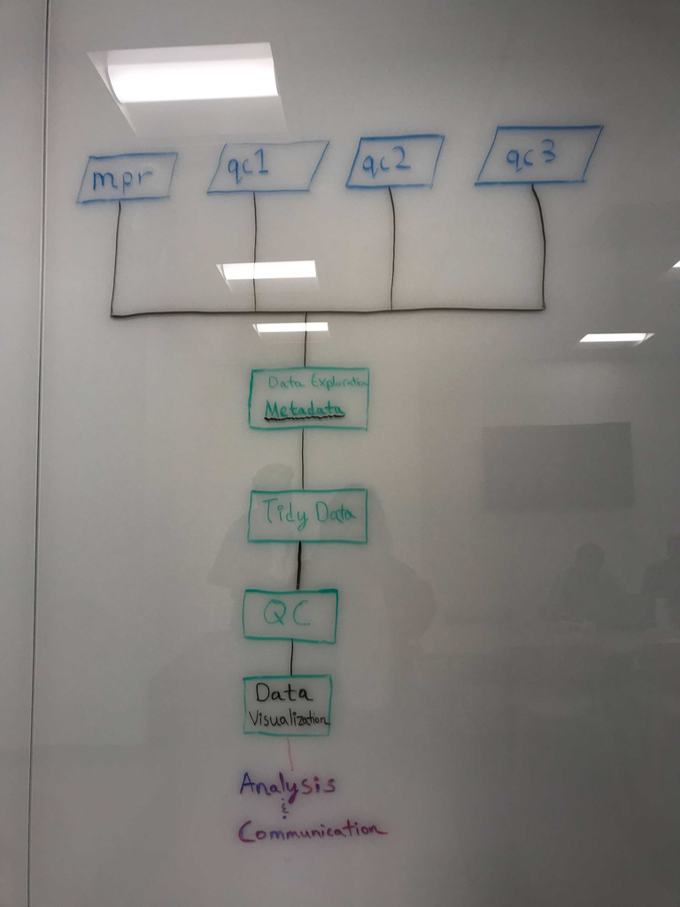

New Workflow.

## Git workflow

Alex Vand created the github repository. Desik Somasundaram and Mia Forsline cloned the repo and made changes on their virtual machine account and then pushed changes back to the github repo.

## Pair programming

Our group used the pair programming approach with one driver and two navigators. The navigators searched online to support the driver and also examined the metadata to ensure consistency and accuracy among the different datasets.

## Challenges

One of key challenges was establishing the initial Github workflow among team members. We had issues regarding push/pull permissions and Personal Access Tokens on the remote server that had to resolved before proceeding with our coding.

We also had some issues with the remote server lagging which required killing active R sessions and restarting.

The collaborative workflow was a new experience for our team so we had to get acquainted with everyone’s pace and learn to speak in technical language that is easy to understand for everyone in the group, especially during pair programming.

## Attach required packages

```r
knitr::opts_chunk$set(echo = TRUE, warning = FALSE, message = FALSE)
library(tidyverse)
library(here)
library(janitor)
library(ggplot2)
library(patchwork)
```

## Read in the data, identifying unique NA values

```r
# Make for loop here
qc1 <- read_csv("/courses/EDS214/eds214-dammad-coders/data/raw_data/QuebradaCuenca1-Bisley.csv", na = c("-9999", "-9999.00", "-9999.0")) %>%
  clean_names()

qc2 <- read_csv("/courses/EDS214/eds214-dammad-coders/data/raw_data/QuebradaCuenca2-Bisley.csv", na = c("-9999", "-9999.00", "-9999.0")) %>%
  clean_names()

qc3 <- read_csv("/courses/EDS214/eds214-dammad-coders/data/raw_data/QuebradaCuenca3-Bisley.csv", na = c("-9999", "-9999.00", "-9999.0")) %>%
  clean_names()

mpr <- read_csv("/courses/EDS214/eds214-dammad-coders/data/raw_data/RioMameyesPuenteRoto.csv", na = c("-9999", "-9999.00", "-9999.0")) %>%
  clean_names()
```

## Clean/wrangle the data

- Select variables (columns) of interest
- Converted the date to ISO 8601 format
- Renamed columns to include units
- Combined all four datasets

```r
# make a for loop here
qc1_clean <- qc1 %>%
  select(sample_id, code, sample_date, k, no3) %>%
  mutate(sample_date = lubridate::mdy(sample_date)) %>%
  rename(k_mg_L = k, no3_ug_L = no3)

qc2_clean <- qc2 %>%
  select(sample_id, code, sample_date, k, no3) %>%
  mutate(sample_date = lubridate::mdy_hm(sample_date)) %>%
  rename(k_mg_L = k, no3_ug_L = no3)

qc3_clean <- qc3 %>%
  select(sample_id, code, sample_date, k, no3) %>%
  mutate(sample_date = lubridate::mdy(sample_date)) %>%
  rename(k_mg_L = k, no3_ug_L = no3)

mpr_clean <- mpr %>%
  select(sample_id, code, sample_date, k, no3) %>%
  mutate(sample_date = lubridate::mdy(sample_date)) %>%
  rename(k_mg_L = k, no3_ug_L = no3)



combined_sites <- rbind(qc1_clean, qc2_clean, qc3_clean, mpr_clean) %>%
  rename(site_id = sample_id) %>%
  mutate(year = lubridate::year(sample_date))


combined_summary <- combined_sites %>%
  group_by(site_id, year) %>%
  summarize(mean_k = mean(k_mg_L, na.rm = TRUE),
            mean_no3 = mean(no3_ug_L, na.rm = TRUE))
```

## Plotting the data

- Created one plot for K and another for NO3
- Created an aggregated graph using the `patchwork` package!

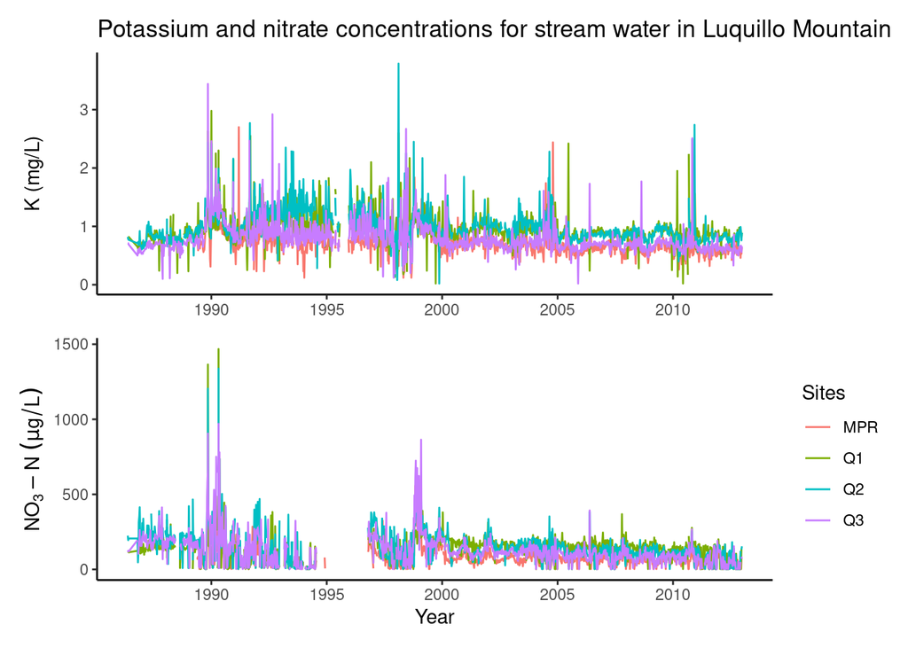

```r
k <- ggplot(data = combined_sites, aes(x = sample_date, y = k_mg_L))+
  geom_line(aes(color = site_id),
            show.legend = FALSE)+
  theme_classic()+
  theme(axis.title.x = element_blank())+
  labs(y = "K (mg/L)",
       color = "Sites",
       title = "Potassium and nitrate concentrations for stream water in Luquillo Mountain")

n <- ggplot(data = combined_sites, aes(x = sample_date, y = no3_ug_L))+
  geom_line(aes(color = site_id)) +
  theme_classic()+
  labs(x = "Year",
       y = expression(paste(NO[3]-N, " ",(mu *g/L))),
       color = "Sites")

k / n
```

## Site map

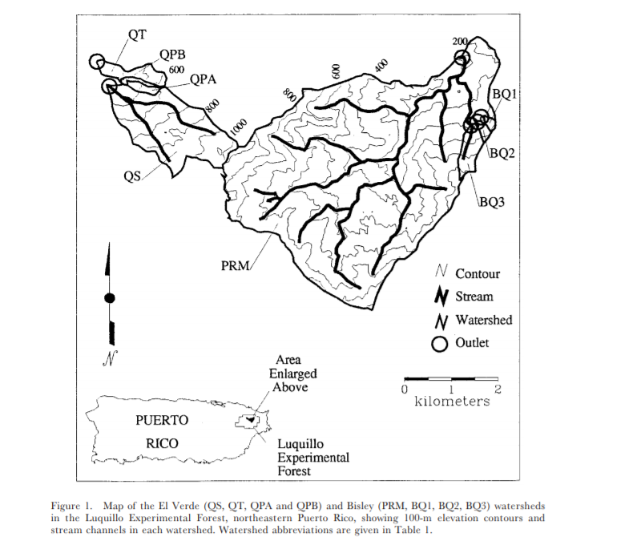

Schaefer et. al. 2000

## Hurricane paths from 1988 to 2012

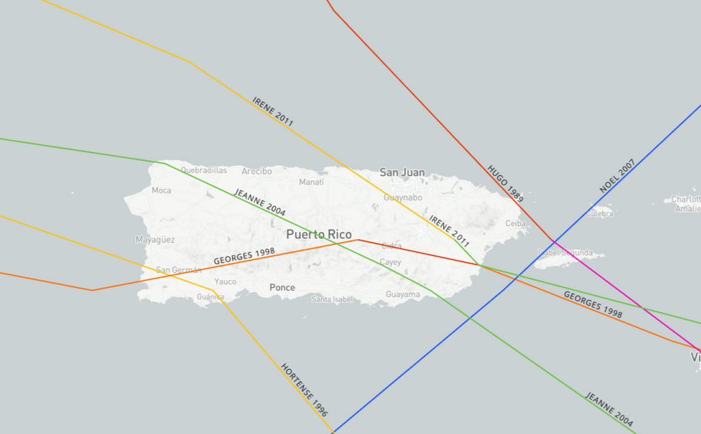

NOAA Hurricane Tracker

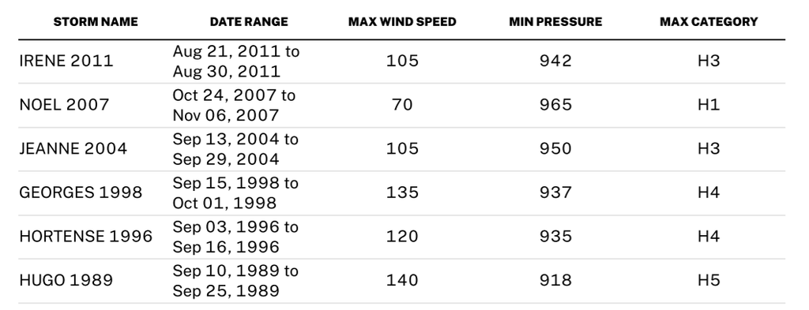

NOAA Hurricane Tracker

## Summary plot

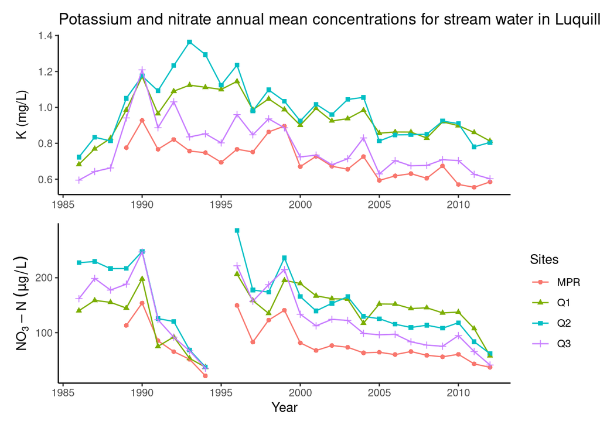

```r
k_summary_plot <- ggplot(data = combined_summary, aes(x = year,
                                                      y = mean_k)) +
  geom_point(aes(color = site_id, shape = site_id)) +
  geom_line(aes(color = site_id)) +
  theme_classic() +
  theme(axis.title.x = element_blank(),
        legend.position = "none") +
  labs(y = "K (mg/L)",
       color = "Sites",
       title = "Potassium and nitrate annual mean concentrations for stream water in Luquillo Mountain")

n_summary_plot <- ggplot(data = combined_summary, aes(x = year,
                                                      y = mean_no3,
                                                      shape = site_id,
                                                      color = site_id)) +
  geom_point() +
  geom_line() +
  theme_classic() +
  labs(x = "Year",
       y = expression(paste(NO[3]-N, " ",(mu *g/L))),
       color = "Sites",
       shape = "Sites")

k_summary_plot / n_summary_plot
```

## Results & Analysis

Nitrate concentration data was not consistently collected from July 1994 to October 1996.

## Further Research

We are interested to determine the statistical significance of our findings and to further explore hypotheses for the high potassium concentration and low nitrate concentration around 1993. Furthermore, we would like to expand this research with the most current data.

## Sources & R packages

H. Wickham. ggplot2: Elegant Graphics for Data Analysis. Springer-Verlag New York, 2016.

Kirill Müller (2020). here: A Simpler Way to Find Your Files. R package version 1.0.1. https://CRAN.R-project.org/package=here

National Oceanic and Atmospheric Administration (NOAA). (n.d.). Historical Hurricane Tracks. Office for Coastal Management. Retrieved August 27, 2021, from https://coast.noaa.gov/hurricanes/#map=4/32/-80

Sam Firke (2021). janitor: Simple Tools for Examining and Cleaning Dirty Data. R package version 2.1.0. https://CRAN.R-project.org/package=janitor

Schaefer, Douglas. A., McDowell, W. H., Scatena, F. N., & Asbury, C. E. (2000). Effects of hurricane disturbance on stream water concentrations and fluxes in eight tropical forest watersheds of the Luquillo Experimental Forest, Puerto Rico. Journal of Tropical Ecology, 16(2), 189–207. https://doi.org/10.1017/S0266467400001358

Thomas Lin Pedersen (2020). patchwork: The Composer of Plots. R package version 1.1.1. https://CRAN.R-project.org/package=patchwork

Wickham et al., (2019). Welcome to the tidyverse. Journal of Open Source Software, 4(43), 1686, https://doi.org/10.21105/joss.01686